# Sparkify Project Workspace

This workspace contains a tiny subset (128MB) of the full dataset available (12GB). Feel free to use this workspace to build your project, or to explore a smaller subset with Spark before deploying your cluster on the cloud. Instructions for setting up your Spark cluster is included in the last lesson of the Extracurricular Spark Course content.

You can follow the steps below to guide your data analysis and model building portion of this project.

```python
# import related PySpark libraries

from pyspark.sql import SparkSession, Window
from pyspark.sql.functions import *
from pyspark.sql.types import *

from pyspark.ml import Pipeline
from pyspark.ml.classification import LogisticRegression, RandomForestClassifier, GBTClassifier
from pyspark.ml.feature import StandardScaler, StringIndexer, VectorAssembler, CountVectorizer, Normalizer
from pyspark.ml.evaluation import MulticlassClassificationEvaluator, RegressionEvaluator
from pyspark.ml.tuning import CrossValidator, ParamGridBuilder
from pyspark.mllib.evaluation import MulticlassMetrics

# import other Python libraries: pandas, matplotlib etc.

import pandas as pd
import numpy as np
import matplotlib.pyplot as plt
import seaborn as sns
import os
import re
import copy
import time
import datetime

%matplotlib inline
```

```python
# create a Spark session, read file and export into df.
spark = SparkSession.builder.getOrCreate()
mini_data = 'mini_sparkify_event_data.json'
df = spark.read.json(mini_data)
# observe 5 records in mini data.
df.head(5)
```

```
[Row(artist='Martha Tilston', auth='Logged In', firstName='Colin', gender='M', itemInSession=50, lastName='Freeman', length=277.89016, level='paid', location='Bakersfield, CA', method='PUT', page='NextSong', registration=1538173362000, sessionId=29, song='Rockpools', status=200, ts=1538352117000, us…
 Row(artist='Five Iron Frenzy', auth='Logged In', firstName='Micah', gender='M', itemInSession=79, lastName='Long', length=236.09424, level='free', location='Boston-Cambridge-Newton, MA-NH', method='PUT', page='NextSong', registration=1538331630000, sessionId=8, song='Canada', status=200, ts=1538352…
 Row(artist='Adam Lambert', auth='Logged In', firstName='Colin', gender='M', itemInSession=51, lastName='Freeman', length=282.8273, level='paid', location='Bakersfield, CA', method='PUT', page='NextSong', registration=1538173362000, sessionId=29, song='Time For Miracles', status=200, ts=153835239400…
 Row(artist='Enigma', auth='Logged In', firstName='Micah', gender='M', itemInSession=80, lastName='Long', length=262.71302, level='free', location='Boston-Cambridge-Newton, MA-NH', method='PUT', page='NextSong', registration=1538331630000, sessionId=8, song='Knocking On Forbidden Doors', status=200,…
 Row(artist='Daft Punk', auth='Logged In', firstName='Colin', gender='M', itemInSession=52, lastName='Freeman', length=223.60771, level='paid', location='Bakersfield, CA', method='PUT', page='NextSong', registration=1538173362000, sessionId=29, song='Harder Better Faster Stronger', status=200, ts=15…
```

# Load and Clean Dataset

In this workspace, the mini-dataset file is `mini_sparkify_event_data.json`. Load and clean the dataset, checking for invalid or missing data - for example, records without userids or sessionids.

```python
# Before starting data cleaning operation, observe dataset in loaded df.
# There are 18 columns including 12 categorical columns (string) and 6 numerical columns (long and double).
df.printSchema()
```

```
root
 |-- artist: string (nullable = true)
 |-- auth: string (nullable = true)
 |-- firstName: string (nullable = true)
 |-- gender: string (nullable = true)
 |-- itemInSession: long (nullable = true)
 |-- lastName: string (nullable = true)
 |-- length: double (nullable = true)
 |-- level: string (nullable = true)
 |-- location: string (nullable = true)
 |-- method: string (nullable = true)
 |-- page: string (nullable = true)
 |-- registration: long (nullable = true)
 |-- sessionId: long (nullable = true)
 |-- song: string (nullable = true)
 |-- status: long (nullable = true)
 |-- ts: long (nullable = true)
 |-- userAgent: string (nullable = true)
 |-- userId: string (nullable = true)
```

```python
# describe dataset for all columns.
df.describe().toPandas()
```

|  | summary | artist | auth | firstName | gender | itemInSession | lastName | length | level | location | method | page | registration | sessionId | song | status | ts | userAgent | userId |
| --- | --- | --- | --- | --- | --- | --- | --- | --- | --- | --- | --- | --- | --- | --- | --- | --- | --- | --- | --- |
| 0 | count | 228108 | 286500 | 278154 | 278154 | 286500 | 278154 | 228108 | 286500 | 278154 | 286500 | 286500 | 278154 | 286500 | 228108 | 286500 | 286500 | 278154 | 286500 |
| 1 | mean | 551.0852017937219 | None | None | None | 114.41421291448516 | None | 249.1171819778458 | None | None | None | None | 1.5353588340844272E12 | 1041.526554973822 | Infinity | 210.05459685863875 | 1.5409568898104834E12 | None | 59682.02278593872 |
| 2 | stddev | 1217.7693079161374 | None | None | None | 129.76726201140994 | None | 99.23517921058361 | None | None | None | None | 3.291321616327586E9 | 726.7762634630741 | NaN | 31.50507848842214 | 1.5075439608226302E9 | None | 109091.9499991047 |
| 3 | min | !!! | Cancelled | Adelaida | F | 0 | Adams | 0.78322 | free | Albany, OR | GET | About | 1521380675000 | 1 | Ãg Ãtti GrÃ¡a Ãsku | 200 | 1538352117000 | "Mozilla/5.0 (Macintosh; Intel Mac OS X 10_10)... |  |
| 4 | max | Ãlafur Arnalds | Logged Out | Zyonna | M | 1321 | Wright | 3024.66567 | paid | Winston-Salem, NC | PUT | Upgrade | 1543247354000 | 2474 | Ãau hafa sloppiÃ° undan Ã¾unga myrkursins | 404 | 1543799476000 | Mozilla/5.0 (compatible; MSIE 9.0; Windows NT ... | 99 |

```python
# There are 286.500 records and 18 columns.
print("Data Shape:", (df.count(), len(df.columns)))
```

```
Data Shape: (286500, 18)
```

```python
# There are records in which userId is empty string.
df.describe('userId').show()
```

```
+-------+-----------------+
|summary|           userId|
+-------+-----------------+
|  count|           286500|
|   mean|59682.02278593872|
| stddev|109091.9499991047|
|    min|                 |
|    max|               99|
+-------+-----------------+
```

```python
# There are 286.500 records and sessionId range is between 1 an 2474.
df.describe('sessionId').show()
```

```
+-------+-----------------+
|summary|        sessionId|
+-------+-----------------+
|  count|           286500|
|   mean|1041.526554973822|
| stddev|726.7762634630741|
|    min|                1|
|    max|             2474|
+-------+-----------------+
```

```python
# After loading and preliminary observation of data above, data cleaning operation is started with these items:
# 1. Drop NaN and '' values (empty strings)

#Check missing values and '' data for each column.
print('Count of Missing Values for each Column')
for col in df.columns:
    missing_count = df.filter((df[col] == "") | df[col].isNull() | isnan(df[col])).count()
    print('{}: '.format(col), missing_count)
```

```
Count of Missing Values for each Column
artist:  58392
auth:  0
firstName:  8346
gender:  8346
itemInSession:  0
lastName:  8346
length:  58392
level:  0
location:  8346
method:  0
page:  0
registration:  8346
sessionId:  0
song:  58392
status:  0
ts:  0
userAgent:  8346
userId:  8346
```

```python
# There are 8.346 missing values for userId and other related columns (firstname, lastname etc.) These records should be dropped.
# There are also 58.392 missing values for artist and song. However, they can be acceptable, because all Sparkify transaction is not related with play song in data.

# Clean data: Drop NaN and '' values (empty strings) : 8.346 of 286.500 = %3 of data is dropped.
df_clean = df.filter((df['userId'] != "") & df['userId'].isNotNull() & ~isnan(df['userId']))
df_clean = df_clean.filter((df_clean['sessionId'].isNotNull()) & (~isnan(df_clean['sessionId'])))
```

```python
#Check missing values and '' data for each column after cleaning operation:
print('Count of Missing Values for each Column')
for col in df_clean.columns:
    missing_count = df_clean.filter((df[col] == "") | df_clean[col].isNull() | isnan(df_clean[col])).count()
    print('{}: '.format(col), missing_count)
```

```
Count of Missing Values for each Column
artist:  50046
auth:  0
firstName:  0
gender:  0
itemInSession:  0
lastName:  0
length:  50046
level:  0
location:  0
method:  0
page:  0
registration:  0
sessionId:  0
song:  50046
status:  0
ts:  0
userAgent:  0
userId:  0
```

```python
# 2. Create two columns and convert ts and registration columns to time stamp format. They show registration and transaction dates of user action.
convert_ts = udf(lambda x: datetime.datetime.fromtimestamp(x / 1000.0).strftime("%Y-%m-%d %H:%M:%S"))
df_clean = df_clean.withColumn('page_event_time', convert_ts('ts'))
df_clean = df_clean.withColumn('registration_time', convert_ts('registration'))
```

```python
# 3. Split location columns to define state.
import pyspark.sql.functions as f
split_col = f.split(df_clean['location'], ',')
df_clean = df_clean.withColumn('City', split_col.getItem(0))
df_clean = df_clean.withColumn('State', split_col.getItem(1))
```

```python
# Observe data after completion of data cleaning operation. Observe top 5 records in clean df.
df_clean.toPandas().head()
```

|  | artist | auth | firstName | gender | itemInSession | lastName | length | level | location | method | ... | sessionId | song | status | ts | userAgent | userId | page_event_time | registration_time | City | State |
| --- | --- | --- | --- | --- | --- | --- | --- | --- | --- | --- | --- | --- | --- | --- | --- | --- | --- | --- | --- | --- | --- |
| 0 | Martha Tilston | Logged In | Colin | M | 50 | Freeman | 277.89016 | paid | Bakersfield, CA | PUT | ... | 29 | Rockpools | 200 | 1538352117000 | Mozilla/5.0 (Windows NT 6.1; WOW64; rv:31.0) G... | 30 | 2018-10-01 00:01:57 | 2018-09-28 22:22:42 | Bakersfield | CA |
| 1 | Five Iron Frenzy | Logged In | Micah | M | 79 | Long | 236.09424 | free | Boston-Cambridge-Newton, MA-NH | PUT | ... | 8 | Canada | 200 | 1538352180000 | "Mozilla/5.0 (Windows NT 6.1; WOW64) AppleWebK... | 9 | 2018-10-01 00:03:00 | 2018-09-30 18:20:30 | Boston-Cambridge-Newton | MA-NH |
| 2 | Adam Lambert | Logged In | Colin | M | 51 | Freeman | 282.82730 | paid | Bakersfield, CA | PUT | ... | 29 | Time For Miracles | 200 | 1538352394000 | Mozilla/5.0 (Windows NT 6.1; WOW64; rv:31.0) G... | 30 | 2018-10-01 00:06:34 | 2018-09-28 22:22:42 | Bakersfield | CA |
| 3 | Enigma | Logged In | Micah | M | 80 | Long | 262.71302 | free | Boston-Cambridge-Newton, MA-NH | PUT | ... | 8 | Knocking On Forbidden Doors | 200 | 1538352416000 | "Mozilla/5.0 (Windows NT 6.1; WOW64) AppleWebK... | 9 | 2018-10-01 00:06:56 | 2018-09-30 18:20:30 | Boston-Cambridge-Newton | MA-NH |
| 4 | Daft Punk | Logged In | Colin | M | 52 | Freeman | 223.60771 | paid | Bakersfield, CA | PUT | ... | 29 | Harder Better Faster Stronger | 200 | 1538352676000 | Mozilla/5.0 (Windows NT 6.1; WOW64; rv:31.0) G... | 30 | 2018-10-01 00:11:16 | 2018-09-28 22:22:42 | Bakersfield | CA |

5 rows × 22 columns

```python
# Clean data including record and column counts: 278.154 records and 22 columns.
# City, State, page_event_time and registration_time columns are created in Spark Dataframe.
df_clean.toPandas().shape
```

```
(278154, 22)
```

# Exploratory Data Analysis

When you're working with the full dataset, perform EDA by loading a small subset of the data and doing basic manipulations within Spark. In this workspace, you are already provided a small subset of data you can explore.

### Define Churn

Once you've done some preliminary analysis, create a column `Churn` to use as the label for your model. I suggest using the `Cancellation Confirmation` events to define your churn, which happen for both paid and free users. As a bonus task, you can also look into the `Downgrade` events.

### Explore Data

Once you've defined churn, perform some exploratory data analysis to observe the behavior for users who stayed vs users who churned. You can start by exploring aggregates on these two groups of users, observing how much of a specific action they experienced per a certain time unit or number of songs played.

```python
# Explore clean data (df_clean) using sparksql
# There are 121 male and 104 female users in data frame. It is approximately balanced data according to gender.
df_clean.createOrReplaceTempView("Sparkify_df_clean")
spark.sql('''
        SELECT gender,COUNT(DISTINCT userId) AS user_counts
        FROM Sparkify_df_clean
        GROUP BY gender
        ORDER BY user_counts DESC
''').show()
```

```
+------+-----------+
|gender|user_counts|
+------+-----------+
|     M|        121|
|     F|        104|
+------+-----------+
```

```python
# Majority of page event data is composed of "NextSong" (80% of data: 228.108 / 278.154)
# Cancel Confirmation page event is also 52 and this event will be used to define churn.
spark.sql('''
        SELECT page,COUNT(userId) AS user_counts
        FROM Sparkify_df_clean
        GROUP BY page
        ORDER BY user_counts DESC
''').show()
```

```
+--------------------+-----------+
|                page|user_counts|
+--------------------+-----------+
|            NextSong|     228108|
|           Thumbs Up|      12551|
|                Home|      10082|
|     Add to Playlist|       6526|
|          Add Friend|       4277|
|         Roll Advert|       3933|
|              Logout|       3226|
|         Thumbs Down|       2546|
|           Downgrade|       2055|
|            Settings|       1514|
|                Help|       1454|
|             Upgrade|        499|
|               About|        495|
|       Save Settings|        310|
|               Error|        252|
|      Submit Upgrade|        159|
|    Submit Downgrade|         63|
|              Cancel|         52|
|Cancellation Conf...|         52|
+--------------------+-----------+
```

```python
# There are 195 free and 165 paid account in this dataset. There are 225 userIds in dataframe, so it shows that 135 users have changed their account level.
spark.sql('''
        SELECT level,COUNT(DISTINCT userId) AS user_counts
        FROM  Sparkify_df_clean
        GROUP BY level
        ORDER BY user_counts DESC
''').show()
```

```
+-----+-----------+
|level|user_counts|
+-----+-----------+
| free|        195|
| paid|        165|
+-----+-----------+
```

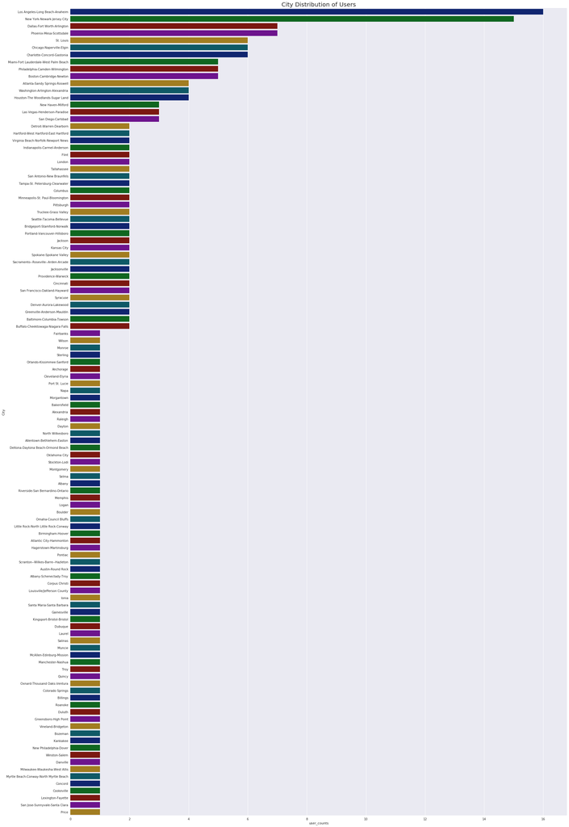

```python
# City distribution of users is showed below. LA and NY are top cities.
city_dist = spark.sql('''
        SELECT City,COUNT(DISTINCT userId) AS user_counts
        FROM Sparkify_df_clean
        GROUP BY City
        ORDER BY user_counts DESC
''').toPandas()

# Plot graph for distribution
sns.set(rc={'figure.figsize':(30,50)})
plt.title('City Distribution of Users', size=20)
barplot = sns.barplot(x = 'user_counts', y = 'City', data = city_dist, palette = 'dark')
plt.show()
```

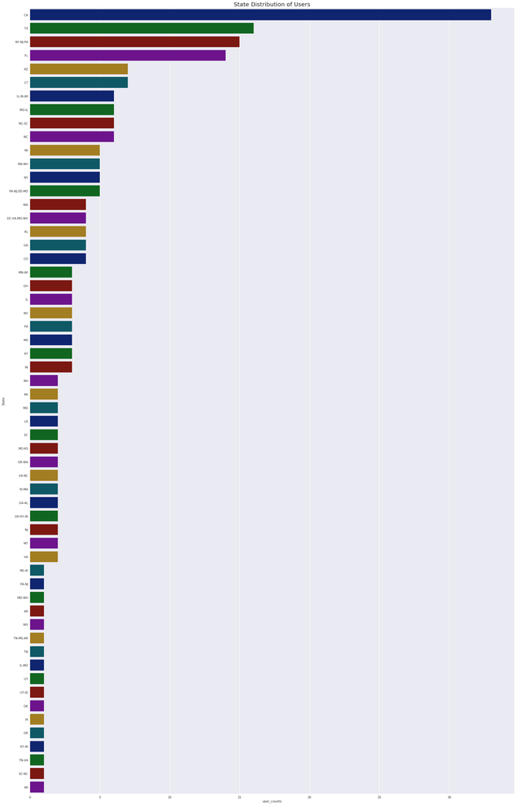

```python
# Majority of Users are in CA, TX, NY-NJ-PA, FL states.
state_dist = spark.sql('''
        SELECT State,COUNT(DISTINCT userId) AS user_counts
        FROM Sparkify_df_clean
        GROUP BY State
        ORDER BY user_counts DESC
''').toPandas()

# Plot graph for distribution
sns.set(rc={'figure.figsize':(30,50)})
plt.title('State Distribution of Users', size=20)
barplot = sns.barplot(x = 'user_counts', y = 'State', data = state_dist, palette = 'dark')
plt.show()
```

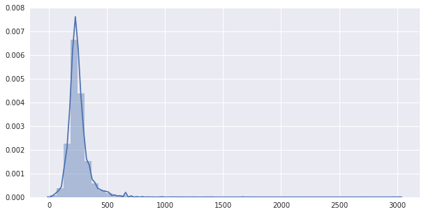

```python
# Length of time for current row of specific log and show distribution of length of event logs
# Majority of lenght is between 0 and 500 minutes.
length_data = spark.sql('''
        SELECT length
        FROM Sparkify_df_clean
''')
sns.set(rc={'figure.figsize':(10,5)})
sns.distplot(length_data.toPandas().dropna());
```

```python
# Define churn label with Cancellation Confirmation page event
churn_page_event = udf(lambda x: 1 if x == 'Cancellation Confirmation' else 0, IntegerType())
df_clean = df_clean.withColumn('Churn_Event', churn_page_event('page'))
windowval = Window.partitionBy('userId')
df_clean = df_clean.withColumn('Churn_Flag', max('Churn_Event').over(windowval))
```